# Project_4

Sarah Eiben, Michelle Baumgartner, Deni Hodzic

2022-06-14

```r
load("objects_p3.RData")
```

# Clustering of the signals and enrichment analysis

Our second approach to compare the different family members with each other is to cluster the signals and do an enrichment analysis with the clusters. After plotting the signals in a combined heatmap, the signals will be clustered and analyzed in an enrichment analysis.

```r
suppressPackageStartupMessages({
  library(GenomicRanges)
  library(epiwraps)
  library(ggplot2)
  library(rGREAT)
  library(AnnotationHub)
  library(Rsubread)
  library(rtracklayer)
  library(Biostrings)
  library(Rfastp)
  library(ensembldb)
  library(bsseq)
  library(BiocParallel)
  library(edgeR)
  library(DMRcate)
})
```

## Plotting the signals

As regions we are going to be using the peaks from the different CREB family members that we downloaded in Project_2 and the tracks are the corresponding signal p-values. We make a list of the signal p-values of the CREB family members. Then we also make a list of the peak values and merge them together to create one long list of non-overlapping regions. Finally we combine these in a matrix and create a heatmap.

```r
# create a list with all the peaks on chromosome 1
peak_list <- GRangesList("Peaks CREB1"=peaks_creb1_chr1, "Peaks CREB3"=peaks_creb3_chr1, "Peaks CREB3L1"=peaks_creb3l1_chr1, "Peaks CREB5"=peaks_creb5_chr1, compress=TRUE)
# merge the peaks together to create one list of non-overlapping regions
merged_peaks <- reduce(unlist(peak_list))
# make a list of the signal p-values
pv_list <- list(CREB1="signal_pv_creb/signal_pv_creb1.bw", CREB3="signal_pv_creb/signal_pv_creb3.bw", CREB3L1="signal_pv_creb/signal_pv_creb3l1.bw", CREB5="signal_pv_creb/Signal_pv_creb5.bw")
# we obtain the matrix of the signal around the regions:
m_creb1 <- signal2Matrix(pv_list, merged_peaks)
```

```
## Reading signal_pv_creb/signal_pv_creb1.bw
```

```
## Reading signal_pv_creb/signal_pv_creb3.bw
```

```
## Reading signal_pv_creb/signal_pv_creb3l1.bw
```

```
## Reading signal_pv_creb/Signal_pv_creb5.bw
```

```
## `use_raster` is automatically set to TRUE for a matrix with more than
## 2000 rows. You can control `use_raster` argument by explicitly setting
## TRUE/FALSE to it.
##
## Set `ht_opt$message = FALSE` to turn off this message.
```

[output not shown]

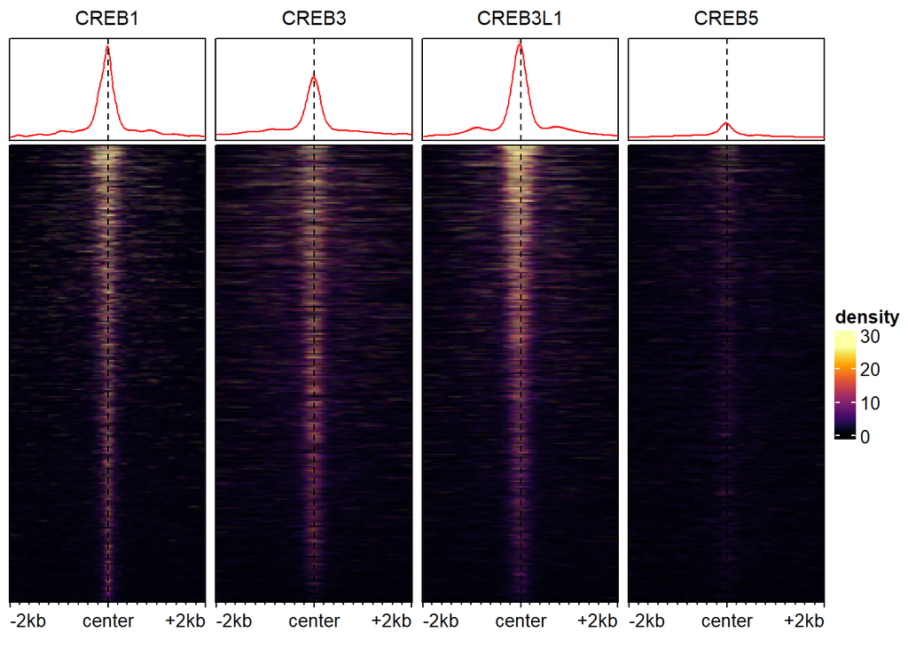

```r
# maybe set an extend and a width?
plotEnrichedHeatmaps(m_creb1)
```

Figure 4.1: A heatmap of the CREB family member signals.

Each row represents the same region across the heatmaps.

Here you can see that there are strongest signals in CREB3L1, followed by similar looking CREB1 and CREB3 and rather weak looking CREB5.